# R Notebook

資料來源:此資源來源於KAGGLE(https://www.kaggle.com/code/warathep11/video-games-sales-r)。

資料敘述:資料內容為1980-2018遊戲銷售內容(包含:PS4.XBOX.PC等),包含:遊戲名稱,遊戲平台,遊戲發行年,遊戲類型,遊戲出版商,以及遊戲銷售量(包含北美,歐洲,日本,其他,以及總銷售量)。

研究動機:欲了解遊戲的銷售情況受何種因素影響,例如:市場上銷量最好的遊戲比起其他遊戲的具有什麼不同,此因素可能是遊戲類型,發行年分等,而本研究目的之一便是了解各變數之於銷售的影響。

[figure not shown]

```r
knitr::include_graphics("https://attach.setn.com/newsimages/2021/06/29/3210292-PH.jpg")
```

```r
vdo<- read.csv("C:\\Users\\user\\Desktop\\Video_Games.csv")
ps4 <- read.csv("C:\\Users\\user\\Desktop\\PS4_GamesSales.csv")
xbox <- read.csv("C:\\Users\\user\\Desktop\\XboxOne_GameSales.csv")
```

```r
library(dplyr)
```

```r
library(tidyr)
library(stringr)
library(ggplot2)
library(corrplot)
library(dummies)
library(broom)
library(mice)
library(DataExplorer)
library(gridExtra)
library(caret)
library(RColorBrewer)
library(missForest)
library(caTools)
library(jtools)
library(randomForest)
library(e1071)
library(ROCR)
library(klaR)
library(tidyverse)
library(naniar)
library(VIM)
library(FactoMineR)
library(missMDA)
library(olsrr)
#sapply(ps4,anyNA)
```

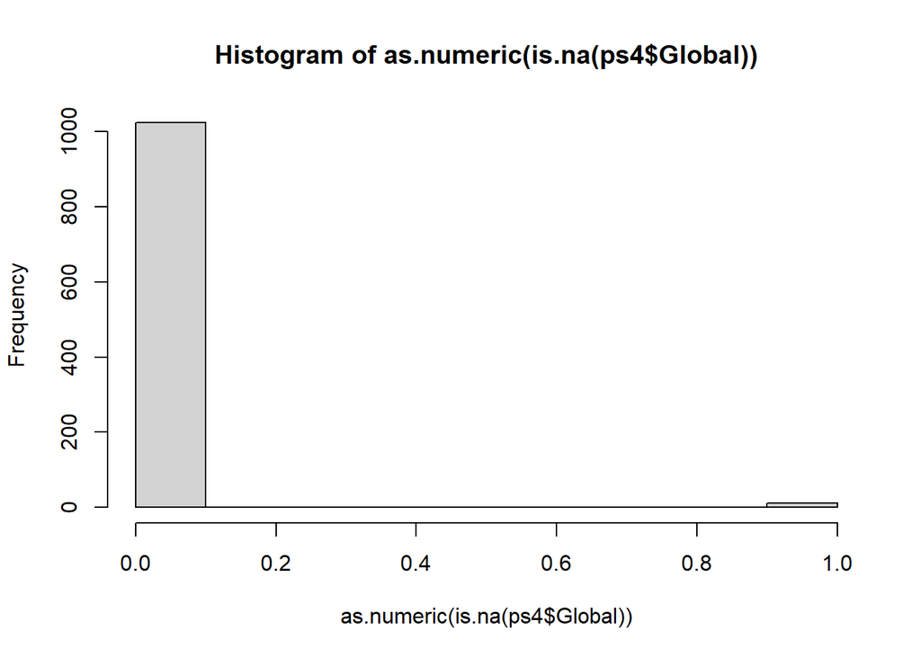

```r
hist(as.numeric(is.na(ps4$Global)))
```

```r
summary(as.numeric(is.na(ps4$Global)))
```

```
##    Min. 1st Qu.  Median    Mean 3rd Qu.    Max.
## 0.00000 0.00000 0.00000 0.01064 0.00000 1.00000
```

```r
table(as.numeric(is.na(ps4$Global)))
```

```
##
##    0    1
## 1023   11
```

```r
#sapply(xbox,anyNA)
```

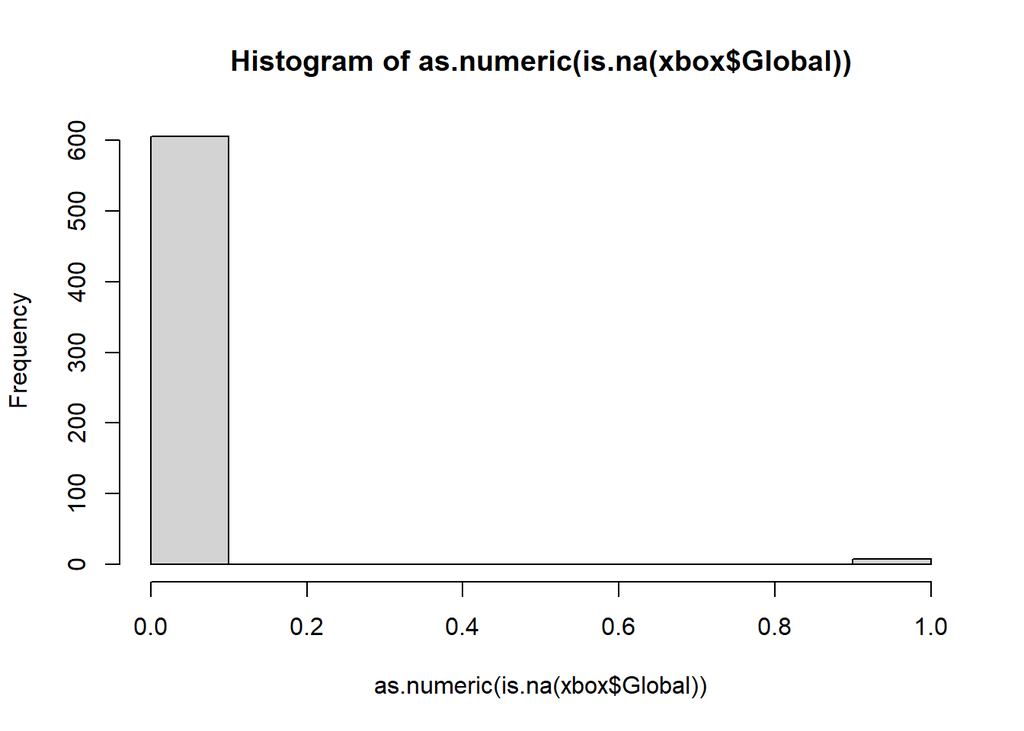

```r
hist(as.numeric(is.na(xbox$Global)))
```

```r
#summary(as.numeric(is.na(xbox$Global)))

table(as.numeric(is.na(xbox$Global)))
```

```
##
##   0   1
## 605   8
```

```r
#sapply(vdo,anyNA)
```

```r
table(as.numeric(is.na(vdo$Global_Sales )))
```

```
##
##     0     1
## 16717     2
```

```r
table(as.numeric(is.na(vdo$Critic_Score     )))
```

```
##
##    0    1
## 8137 8582
```

```r
table(as.numeric(is.na(vdo$Critic_Count           )))
```

```
##
##    0    1
## 8137 8582
```

```r
table(as.numeric(is.na(vdo$User_Score                 )))
```

```
##
##    0    1
## 7590 9129
```

```r
table(as.numeric(is.na(vdo$User_Count                  )))
```

```
##
##    0    1
## 7590 9129
```

資料預處理

```r
#PS4
na.omit(ps4)
```

|  | Game | Year | Genre | Publisher | North.America | Europe | Japan | Rest.of.World | Global |
| --- | --- | --- | --- | --- | --- | --- | --- | --- | --- |
| 1 | Grand Theft Auto V | 2014 | Action | Rockstar Games | 6.06 | 9.71 | 0.60 | 3.02 | 19.39 |
| 2 | Call of Duty: Black Ops 3 | 2015 | Shooter | Activision | 6.18 | 6.05 | 0.41 | 2.44 | 15.09 |
| 3 | Red Dead Redemption 2 | 2018 | Action-Adventure | Rockstar Games | 5.26 | 6.21 | 0.21 | 2.26 | 13.94 |
| 4 | Call of Duty: WWII | 2017 | Shooter | Activision | 4.67 | 6.21 | 0.40 | 2.12 | 13.40 |
| 5 | FIFA 18 | 2017 | Sports | EA Sports | 1.27 | 8.64 | 0.15 | 1.73 | 11.80 |
| 6 | FIFA 17 | 2016 | Sports | Electronic Arts | 1.26 | 7.95 | 0.12 | 1.61 | 10.94 |
| 7 | Uncharted (PS4) | 2016 | Action | Sony Interactive Entertainment | 4.49 | 3.93 | 0.21 | 1.70 | 10.33 |
| 8 | Spider-Man (PS4) | 2018 | Action-Adventure | Sony Interactive Entertainment | 3.64 | 3.39 | 0.32 | 1.41 | 8.76 |
| 9 | Call of Duty: Infinite Warfare | 2016 | Shooter | Activision | 3.11 | 3.83 | 0.19 | 1.36 | 8.48 |
| 10 | Fallout 4 | 2015 | Role-Playing | Bethesda Softworks | 2.91 | 3.97 | 0.27 | 1.34 | 8.48 |

[output cut: 1013 more lines]

```r
ps4$Year <- as.integer(ps4$Year)
#Xbox
na.omit(xbox)
```

|  | Pos | Game | Year | Genre | Publisher | North.America | Europe | Japan | Rest.of.World | Global |
| --- | --- | --- | --- | --- | --- | --- | --- | --- | --- | --- |
| 1 | 1 | Grand Theft Auto V | 2014 | Action | Rockstar Games | 4.70 | 3.25 | 0.01 | 0.76 | 8.72 |
| 2 | 2 | Call of Duty: Black Ops 3 | 2015 | Shooter | Activision | 4.63 | 2.04 | 0.02 | 0.68 | 7.37 |
| 3 | 3 | Call of Duty: WWII | 2017 | Shooter | Activision | 3.75 | 1.91 | 0.00 | 0.57 | 6.23 |
| 4 | 4 | Red Dead Redemption 2 | 2018 | Action-Adventure | Rockstar Games | 3.76 | 1.47 | 0.00 | 0.54 | 5.77 |
| 5 | 5 | MineCraft | 2014 | Misc | Microsoft Studios | 3.23 | 1.71 | 0.00 | 0.49 | 5.43 |
| 6 | 6 | Call of Duty: Advanced Warfare | 2014 | Shooter | Activision | 3.25 | 1.49 | 0.01 | 0.48 | 5.22 |
| 7 | 7 | Battlefield 1 | 2016 | Shooter | Electronic Arts | 3.37 | 1.26 | 0.02 | 0.48 | 5.13 |
| 8 | 8 | Fallout 4 | 2015 | Role-Playing | Bethesda Softworks | 2.94 | 1.62 | 0.02 | 0.45 | 5.03 |
| 9 | 9 | Halo 5: Guardians | 2015 | Shooter | Microsoft Studios | 2.94 | 1.49 | 0.03 | 0.45 | 4.92 |
| 10 | 10 | Call of Duty: Infinite Warfare | 2016 | Shooter | Activision | 2.91 | 1.44 | 0.00 | 0.44 | 4.79 |

[output cut: 595 more lines]

```r
xbox$Year <- as.integer(xbox$Year)
#All VDO Games
na.omit(vdo)
```

|  | Name | Platform | Year_of_Release | Genre | Publisher | NA_Sales | EU_Sales | JP_Sales | Other_Sales | Global_Sales | Critic_Score | Critic_Count | User_Score | User_Count | Developer | Rating |
| --- | --- | --- | --- | --- | --- | --- | --- | --- | --- | --- | --- | --- | --- | --- | --- | --- |
| 1 | Wii Sports | Wii | 2006 | Sports | Nintendo | 41.36 | 28.96 | 3.77 | 8.45 | 82.53 | 76 | 51 | 8.0 | 322 | Nintendo | E |
| 3 | Mario Kart Wii | Wii | 2008 | Racing | Nintendo | 15.68 | 12.76 | 3.79 | 3.29 | 35.52 | 82 | 73 | 8.3 | 709 | Nintendo | E |
| 4 | Wii Sports Resort | Wii | 2009 | Sports | Nintendo | 15.61 | 10.93 | 3.28 | 2.95 | 32.77 | 80 | 73 | 8.0 | 192 | Nintendo | E |
| 7 | New Super Mario Bros. | DS | 2006 | Platform | Nintendo | 11.28 | 9.14 | 6.50 | 2.88 | 29.80 | 89 | 65 | 8.5 | 431 | Nintendo | E |
| 8 | Wii Play | Wii | 2006 | Misc | Nintendo | 13.96 | 9.18 | 2.93 | 2.84 | 28.92 | 58 | 41 | 6.6 | 129 | Nintendo | E |
| 9 | New Super Mario Bros. Wii | Wii | 2009 | Platform | Nintendo | 14.44 | 6.94 | 4.70 | 2.24 | 28.32 | 87 | 80 | 8.4 | 594 | Nintendo | E |
| 12 | Mario Kart DS | DS | 2005 | Racing | Nintendo | 9.71 | 7.47 | 4.13 | 1.90 | 23.21 | 91 | 64 | 8.6 | 464 | Nintendo | E |
| 14 | Wii Fit | Wii | 2007 | Sports | Nintendo | 8.92 | 8.03 | 3.60 | 2.15 | 22.70 | 80 | 63 | 7.7 | 146 | Nintendo | E |
| 15 | Kinect Adventures! | X360 | 2010 | Misc | Microsoft Game Studios | 15.00 | 4.89 | 0.24 | 1.69 | 21.81 | 61 | 45 | 6.3 | 106 | Good Science Studio | E |
| 16 | Wii Fit Plus | Wii | 2009 | Sports | Nintendo | 9.01 | 8.49 | 2.53 | 1.77 | 21.79 | 80 | 33 | 7.4 | 52 | Nintendo | E |

[output cut: 7007 more lines]

```r
vdo <- vdo %>%
rename(Year = 'Year_of_Release')
vdo$Year <- as.integer(vdo$Year)
#Data as of 2016
vdo <- vdo %>%
filter(Year<=2016)
```

觀察遊戲銷售量隨著年增加

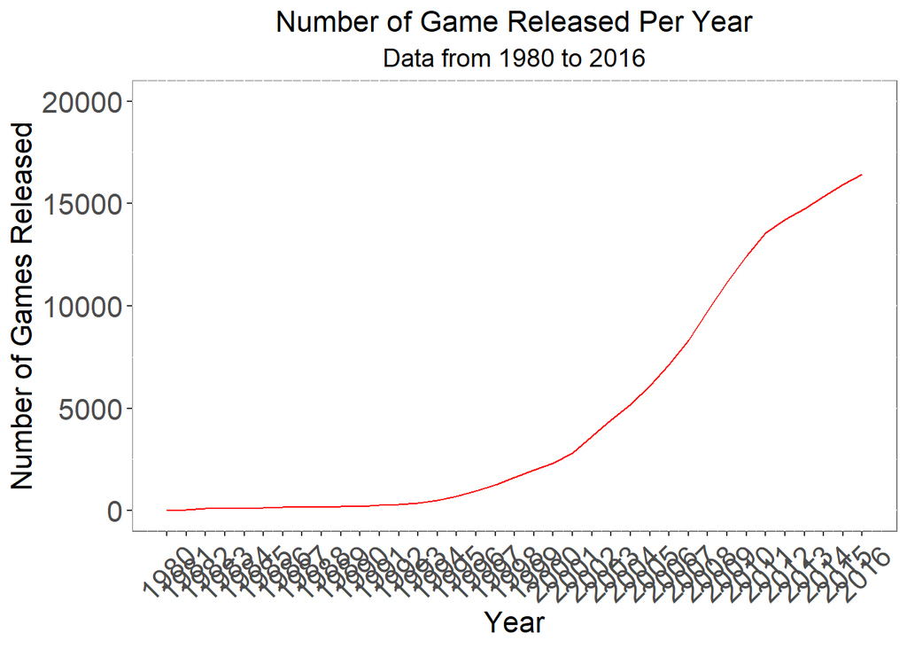

```r
game_released <- vdo %>%
group_by(Year) %>%
summarize(number_of_games_released = n()) %>%
arrange(Year) %>%
mutate(cumsum_number_of_games_released=cumsum(number_of_games_released))

#Plot
options(repr.plot.width = 14, repr.plot.height = 8)
ggplot(game_released,aes(Year,cumsum_number_of_games_released)) +
geom_line(col='red') +
scale_x_continuous(breaks=c(1980:2016)) +
ylim(0,20000) +
theme(plot.title = element_text(hjust=0.5,size=16),
      axis.text.x = element_text(size=16,angle=45,vjust=0.5),
     axis.text.y = element_text(size=16),
     axis.title = element_text(size=16),
     legend.text=element_text(size=16),
     legend.title=element_text(size=16),
     plot.subtitle = element_text(hjust=0.5,size=14),
     panel.background = element_rect(fill = 'white', colour = 'grey50')) +
labs(x='Year',y='Number of Games Released',title='Number of Game Released Per Year',subtitle='Data from 1980 to 2016')
```

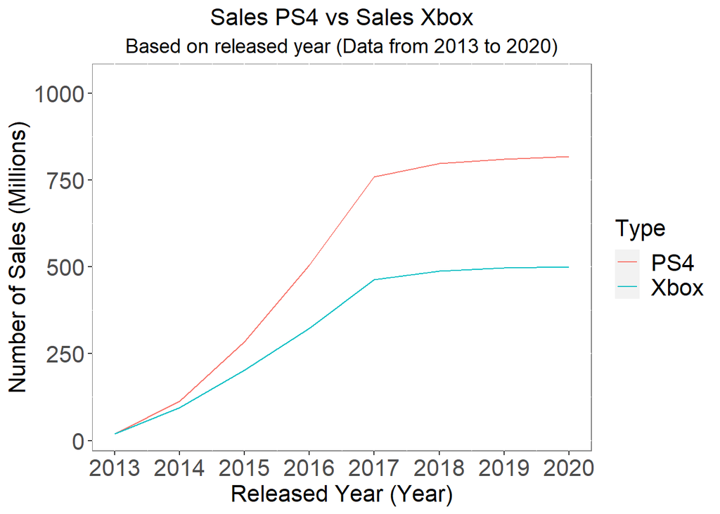

```r
#Data Manipulation (PS4)
ps4_year <- ps4 %>%
group_by(Year) %>%
summarize(number_of_games_sale = n()) %>%
arrange(Year) %>%
mutate(cumsum_sales = cumsum(number_of_games_sale))

#Data Manipulation  (Xbox)
xbox_year <- xbox %>%
group_by(Year) %>%
summarize(number_of_games_sale = n()) %>%
arrange(Year) %>%
mutate(cumsum_sales = cumsum(number_of_games_sale))

#Plot
options(repr.plot.width = 14, repr.plot.height = 8)
ggplot() +
geom_line(ps4_year,
          mapping=aes(Year,cumsum_sales,col='Y1')) +
geom_line(xbox_year,
          mapping=aes(Year,cumsum_sales,col='Y2')) +
scale_color_discrete(name = "Type",
                     labels = c("PS4", "Xbox")) +
labs(x="Released Year (Year)",y="Number of Sales (Millions)",title='Sales PS4 vs Sales Xbox',subtitle='Based on released year (Data from 2013 to 2020)') +
theme(plot.title = element_text(hjust=0.5,size=16),
      axis.text.x = element_text(size=16),
     axis.text.y = element_text(size=16),
     axis.title = element_text(size=16),
     legend.text=element_text(size=16),
     legend.title=element_text(size=16),
     plot.subtitle = element_text(hjust=0.5,size=14),
     panel.background = element_rect(fill = 'white', colour = 'grey50')) +
scale_x_continuous(breaks=c(2013:2020))
```

誰是贏家? 比較PDS,XBOX兩大平台所銷售的遊戲數量 2013-2020年,PS4是贏家

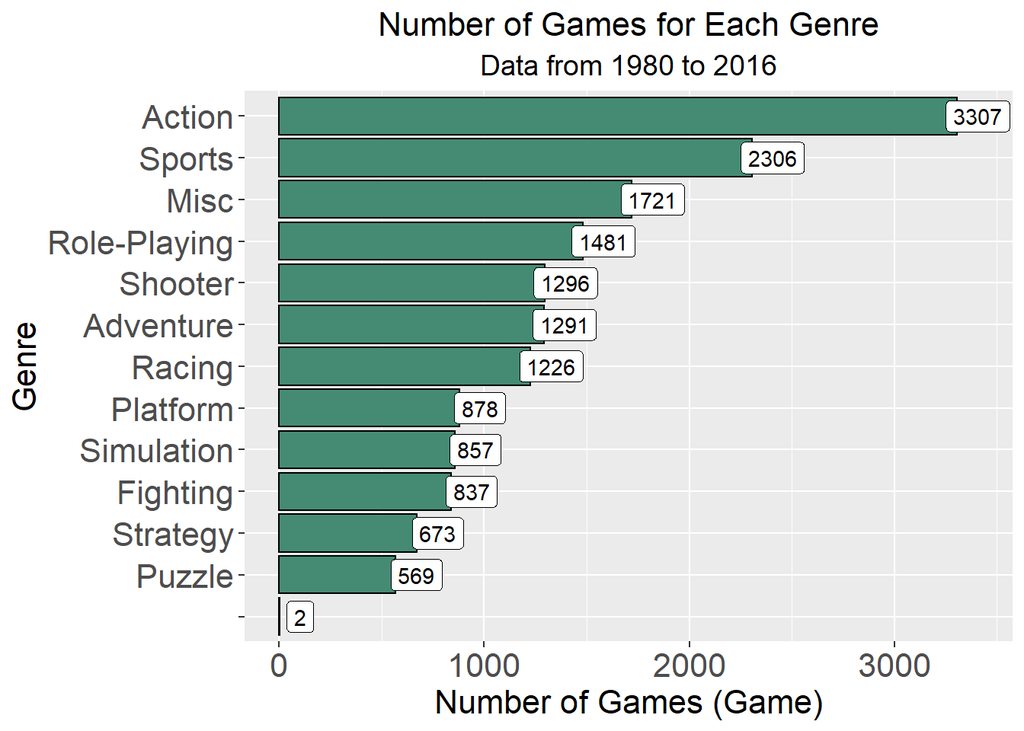

```r
#Data Manipulation
vdo_genre <- vdo %>%
filter(Genre!='NA') %>%
group_by(Genre) %>%
summarize(number_of_games_sale = n()) %>%
arrange(Genre)

#Plot
options(repr.plot.width = 14, repr.plot.height = 8)
ggplot(vdo_genre,aes(reorder(Genre,number_of_games_sale),number_of_games_sale)) +
geom_col(fill='aquamarine4',col='black') +
labs(x='Genre',y='Number of Games (Game)',title='Number of Games for Each Genre',subtitle='Data from 1980 to 2016') +
coord_flip() +
theme(plot.title = element_text(hjust=0.5,size=16),
      axis.text.x = element_text(size=16),
     axis.text.y = element_text(size=16),
     axis.title = element_text(size=16),
     legend.text=element_text(size=16),
     legend.title=element_text(size=16),
     plot.subtitle = element_text(hjust=0.5,size=14)) +
geom_label(aes(label = number_of_games_sale,y=number_of_games_sale + 100))
```

1.前三名:動作,運動,雜項 2.在遊戲中,此三者比例最高 3.由此可以看出動作元素是遊戲重要的元素,顯然市場更傾向有動作元素的電玩遊戲

現在,檢視銷量最高的遊戲是哪些類型

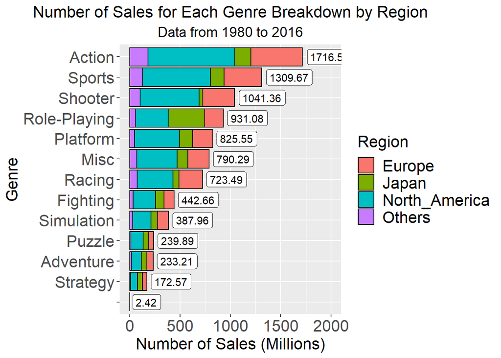

```r
#Data Manipulation
vdo_sale <- vdo %>%
filter(Genre!='NA') %>%
group_by(Genre) %>%
summarize(North_America = sum(NA_Sales),
         Europe = sum(EU_Sales),
         Japan = sum(JP_Sales),
         Others = sum(Other_Sales)) %>%
pivot_longer(North_America:Others,
             names_to='Region',
            values_to='Sales')

#Plot
options(repr.plot.width = 14, repr.plot.height = 8)
ggplot(vdo_sale,aes(reorder(Genre,Sales),
                    Sales,fill=Region)) +
geom_col(col='black') +
labs(x='Genre',y='Number of Sales (Millions)',title = 'Number of Sales for Each Genre Breakdown by Region',subtitle = 'Data from 1980 to 2016') +
theme(plot.title = element_text(hjust=0.5,size=16),
      axis.text.x = element_text(size=16),
     axis.text.y = element_text(size=16),
     axis.title = element_text(size=16),
     legend.text=element_text(size=16),
     legend.title=element_text(size=16),
     plot.subtitle = element_text(hjust=0.5,size=14)) +
coord_flip() +
geom_label(aes(label = stat(y),
              group = Genre),
          stat = 'summary',
          fun = sum,
           hjust = -0.1,
           show.legend = FALSE
  ) +
ylim(0,2000)
```

1.大部分遊戲類型都以北美銷售量最多 2.日本在角色扮演遊戲的銷量中佔有更多的比例

接下來,以地區劃分遊戲在各平台銷量

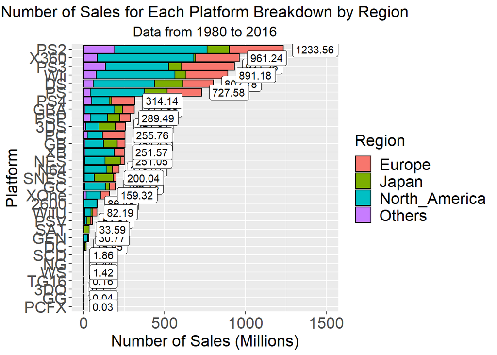

```r
#Data Manipulation
vdo_sale2 <- vdo %>%
group_by(Platform) %>%
summarize(North_America = sum(NA_Sales),
         Europe = sum(EU_Sales),
         Japan = sum(JP_Sales),
         Others = sum(Other_Sales)) %>%
pivot_longer(North_America:Others,
             names_to='Region',
            values_to='Sales')
#Plot
options(repr.plot.width = 14, repr.plot.height = 8)
ggplot(vdo_sale2,aes(reorder(Platform,Sales),
                    Sales,fill=Region)) +
geom_col(col='black') +
coord_flip() +
labs(x='Platform',y='Number of Sales (Millions)',title = 'Number of Sales for Each Platform Breakdown by Region',subtitle='Data from 1980 to 2016') +
theme(plot.title = element_text(hjust=0.5,size=16),
      axis.text.x = element_text(size=16),
     axis.text.y = element_text(size=16),
     axis.title = element_text(size=16),
     legend.text=element_text(size=16),
     legend.title=element_text(size=16),
     plot.subtitle = element_text(hjust=0.5,size=14)) +
geom_label(aes(label = stat(y),
              group = Platform),
          stat = 'summary',
          fun = sum,
           hjust = -0.2,
           show.legend = FALSE
  ) +
ylim(0,1500)
```

1.前幾名接為大眾熟知的遊戲平台,而後有許多是不容易見到的遊戲(機) 2.xbox在日本比例特別低,這與常識符合,PS系列為日本製造

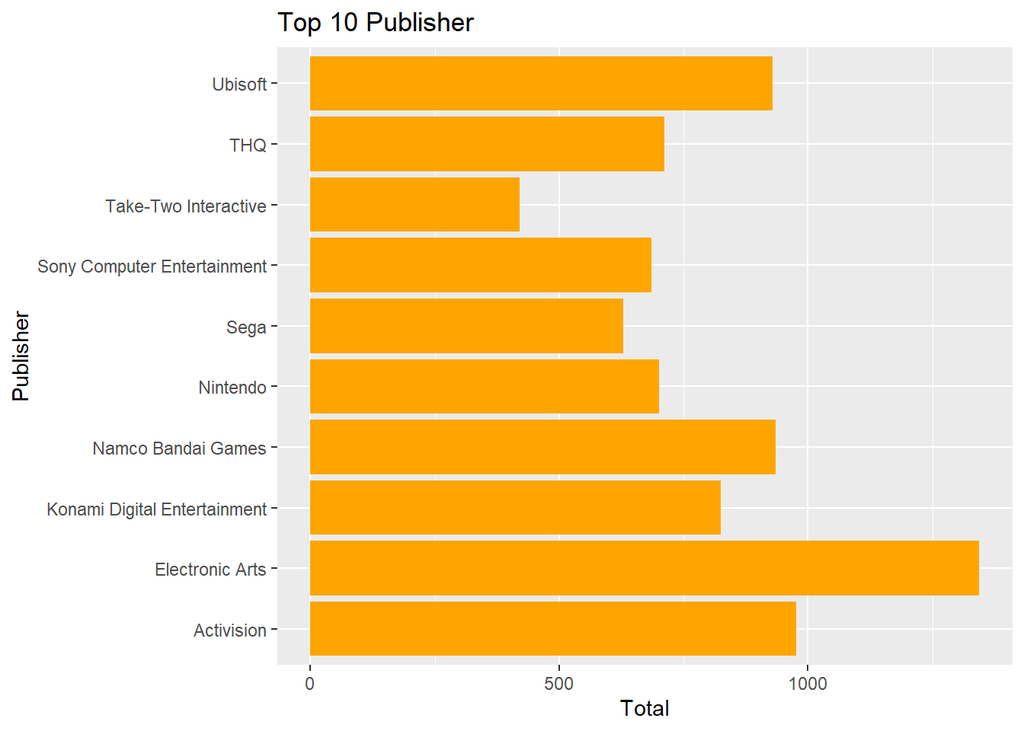

```r
publisher_data <- vdo %>%
  group_by(Publisher) %>%
  summarise(count = n()) %>%
  top_n(n = 10, wt = count) %>%
    arrange(count)




publisher_charts <- ggplot(publisher_data, aes(x = Publisher, y = count, fill=count)) + geom_col(fill="orange")+
  labs(title = "Top 10 Publisher", x="Publisher",y="Total") + coord_flip()

publisher_charts
```

前三名:EA,Activision,Bandai Games

```r
#genre_data <- vdo %>%
#  group_by(Genre) %>%
#  summarise(count = n()) %>%
 # top_n(n = 10, wt = count)


#genre_charts <- ggplot(genre_data, aes(x = Genre, y = count, fill=count)) + #geom_col(fill="red")+
#  labs(title = "Top 10 Genres", x="Genre",y="Total")
#genre_charts
```

```r
#platform_data <- vdo %>%
#  group_by(Platform) %>%
#  summarise(count = n()) %>%
#  top_n(n = 5, wt = count)

#platform_charts <- ggplot(platform_data, aes(x = Platform, y = count, fill=count)) + #geom_col(fill="yellow")+
#  labs(title = "Top 5 Platform", x="Platform",y="Total")
#platform_charts
```

```r
#qplot(x = Genre, data = vdo) + geom_bar(fill = "purple") + coord_flip()  + #facet_wrap(~Rating, nrow = 2)
```

UBISOFT為遊戲老廠牌,著名遊戲為刺客教條等, 在銷量也有不錯的表現,觀察一下他的遊戲銷售情況

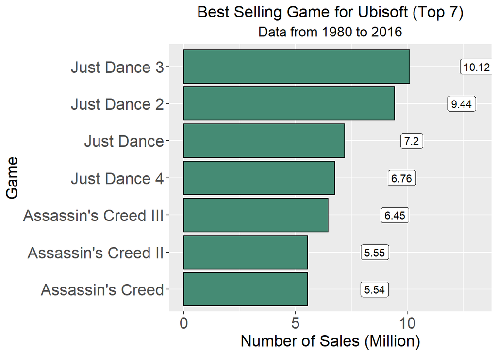

```r
#Data Manipulation
vdo_nin <- vdo %>%
group_by(Name) %>%
filter(Publisher == "Ubisoft") %>%
arrange(desc(Global_Sales)) %>%
head(7)

#Plot
options(repr.plot.width = 14, repr.plot.height = 8)
ggplot(vdo_nin,aes(reorder(Name,Global_Sales),Global_Sales)) +
geom_col(fill='aquamarine4',col='black') +
coord_flip() +
theme(plot.title = element_text(hjust=0.5,size=16),
      axis.text.x = element_text(size=16),
     axis.text.y = element_text(size=16),
     axis.title = element_text(size=16),
     plot.subtitle = element_text(hjust=0.5,size=14)) +
labs(x='Game',
     y="Number of Sales (Million)",
     title='Best Selling Game for Ubisoft (Top 7)',
     subtitle='Data from 1980 to 2016') +
geom_label(aes(label=Global_Sales,y=Global_Sales+3))
```

資料預處理

```r
sales_dataset1 = subset(vdo, select = -c(Name, Publisher, Developer))


# Exp 1 - train:test 70:30, seed 555

set.seed(567)
split = sample.split(sales_dataset1$Global, SplitRatio = 0.7)
train_dataset1 = subset(sales_dataset1, split == TRUE)
test_dataset1 = subset(sales_dataset1, split == FALSE)
```

資料切割為7:3 其中70%作為訓練資料 30%作為測試資料

線性回歸模型

```r
###  Multiple Linear Regression
regressor1 = lm(formula = Global_Sales ~ .,
               data = train_dataset1)
summary(regressor1)
```

```
##
## Call:
## lm(formula = Global_Sales ~ ., data = train_dataset1)
##
## Residuals:
##        Min         1Q     Median         3Q        Max
## -0.0205277 -0.0008589 -0.0001945  0.0004871  0.0202682
##
## Coefficients:
##                     Estimate Std. Error  t value Pr(>|t|)
## (Intercept)        8.726e-02  8.159e-02    1.069   0.2849
## PlatformDC        -6.775e-04  2.125e-03   -0.319   0.7499
## PlatformDS         1.872e-05  6.684e-04    0.028   0.9777
## PlatformGBA       -1.649e-04  8.062e-04   -0.205   0.8379
## PlatformGC        -3.257e-04  7.653e-04   -0.426   0.6704
## PlatformPC         8.842e-04  6.522e-04    1.356   0.1753
## PlatformPS        -1.625e-03  9.648e-04   -1.685   0.0922 .
## PlatformPS2       -5.216e-04  6.872e-04   -0.759   0.4479
## PlatformPS3       -2.729e-04  6.177e-04   -0.442   0.6586
## PlatformPS4        3.645e-04  7.190e-04    0.507   0.6122
## PlatformPSP        3.226e-04  6.947e-04    0.464   0.6423
## PlatformPSV       -1.508e-04  8.380e-04   -0.180   0.8572
## PlatformWii       -8.162e-04  6.536e-04   -1.249   0.2118
## PlatformWiiU      -4.406e-04  9.153e-04   -0.481   0.6302
## PlatformX360      -1.445e-04  6.206e-04   -0.233   0.8159
## PlatformXB         3.853e-05  7.239e-04    0.053   0.9576
## PlatformXOne       6.727e-04  8.057e-04    0.835   0.4038
## Year              -4.293e-05  4.047e-05   -1.061   0.2888
## GenreAdventure    -3.054e-04  4.677e-04   -0.653   0.5138
## GenreFighting     -4.349e-04  4.257e-04   -1.022   0.3070
## GenreMisc         -5.070e-05  4.168e-04   -0.122   0.9032
## GenrePlatform     -4.525e-04  4.214e-04   -1.074   0.2829
## GenrePuzzle        4.553e-04  7.127e-04    0.639   0.5230
## GenreRacing       -6.377e-04  3.782e-04   -1.686   0.0918 .
## GenreRole-Playing -6.350e-04  3.328e-04   -1.908   0.0564 .
## GenreShooter      -2.263e-04  3.093e-04   -0.732   0.4644
## GenreSimulation   -9.351e-04  4.475e-04   -2.090   0.0367 *
## GenreSports       -2.240e-04  3.515e-04   -0.637   0.5240
## GenreStrategy     -5.137e-04  4.992e-04   -1.029   0.3034
## NA_Sales           1.000e+00  1.664e-04 6008.055   <2e-16 ***
## EU_Sales           9.997e-01  2.310e-04 4328.187   <2e-16 ***
## JP_Sales           1.000e+00  3.286e-04 3043.690   <2e-16 ***
## Other_Sales        1.000e+00  4.333e-04 2308.804   <2e-16 ***
## Critic_Score      -2.008e-06  9.069e-06   -0.221   0.8248
## Critic_Count      -6.278e-06  6.016e-06   -1.044   0.2967
## User_Score         5.494e-06  8.163e-05    0.067   0.9463
## User_Count        -1.342e-07  1.764e-07   -0.761   0.4468
## RatingE           -1.198e-04  8.710e-04   -0.138   0.8906
## RatingE10+        -1.177e-04  8.756e-04   -0.134   0.8931
## RatingK-A          1.019e-02  6.048e-03    1.685   0.0921 .
## RatingM           -2.247e-04  8.666e-04   -0.259   0.7954
## RatingRP          -1.112e-02  5.999e-03   -1.854   0.0638 .
## RatingT            3.163e-05  8.568e-04    0.037   0.9705
## ---
## Signif. codes:  0 '***' 0.001 '**' 0.01 '*' 0.05 '.' 0.1 ' ' 1
##
## Residual standard error: 0.005928 on 4759 degrees of freedom
##   (因為不存在，6762 個觀察量被刪除了)
## Multiple R-squared:      1,  Adjusted R-squared:      1
## F-statistic: 1.674e+07 on 42 and 4759 DF,  p-value: < 2.2e-16
```

```r
regressor2 = lm(formula = Global_Sales ~ .-NA_Sales- EU_Sales-JP_Sales-Other_Sales ,
              data = train_dataset1)


summary(regressor2)
```

```
##
## Call:
## lm(formula = Global_Sales ~ . - NA_Sales - EU_Sales - JP_Sales -
##     Other_Sales, data = train_dataset1)
##
## Residuals:
##    Min     1Q Median     3Q    Max
## -7.579 -0.681 -0.193  0.320 79.493
##
## Coefficients:
##                     Estimate Std. Error t value Pr(>|t|)
## (Intercept)        9.138e+01  2.804e+01   3.258 0.001128 **
## PlatformDC        -9.610e-01  7.318e-01  -1.313 0.189130
## PlatformDS         1.503e-01  2.301e-01   0.653 0.513704
## PlatformGBA       -4.872e-01  2.771e-01  -1.758 0.078841 .
## PlatformGC        -6.980e-01  2.629e-01  -2.655 0.007966 **
## PlatformPC        -1.307e+00  2.231e-01  -5.858    5e-09 ***
## PlatformPS         3.210e-01  3.323e-01   0.966 0.334037
## PlatformPS2       -1.797e-01  2.356e-01  -0.763 0.445558
## PlatformPS3       -1.612e-01  2.115e-01  -0.762 0.446120
## PlatformPS4       -4.046e-01  2.457e-01  -1.647 0.099716 .
## PlatformPSP       -3.778e-01  2.385e-01  -1.584 0.113287
## PlatformPSV       -4.124e-01  2.882e-01  -1.431 0.152492
## PlatformWii        8.111e-01  2.241e-01   3.619 0.000299 ***
## PlatformWiiU      -3.382e-01  3.151e-01  -1.073 0.283161
## PlatformX360      -3.784e-01  2.119e-01  -1.786 0.074237 .
## PlatformXB        -8.598e-01  2.482e-01  -3.464 0.000537 ***
## PlatformXOne      -2.022e-01  2.768e-01  -0.731 0.465073
## Year              -4.583e-02  1.391e-02  -3.295 0.000993 ***
## GenreAdventure    -2.710e-01  1.611e-01  -1.683 0.092460 .
## GenreFighting     -2.433e-03  1.465e-01  -0.017 0.986747
## GenreMisc          2.902e-01  1.434e-01   2.024 0.043074 *
## GenrePlatform      4.450e-02  1.451e-01   0.307 0.759020
## GenrePuzzle       -5.932e-01  2.453e-01  -2.418 0.015636 *
## GenreRacing        7.892e-02  1.302e-01   0.606 0.544533
## GenreRole-Playing -2.947e-01  1.133e-01  -2.600 0.009355 **
## GenreShooter       5.991e-02  1.063e-01   0.563 0.573155
## GenreSimulation    1.611e-01  1.541e-01   1.045 0.295885
## GenreSports       -5.343e-02  1.210e-01  -0.442 0.658792
## GenreStrategy     -2.688e-01  1.719e-01  -1.564 0.117879
## Critic_Score       2.863e-02  3.093e-03   9.256  < 2e-16 ***
## Critic_Count       2.328e-02  2.035e-03  11.442  < 2e-16 ***
## User_Score        -1.021e-01  2.803e-02  -3.644 0.000272 ***
## User_Count         8.258e-04  5.908e-05  13.977  < 2e-16 ***
## RatingE            2.216e-02  2.999e-01   0.074 0.941101
## RatingE10+        -4.314e-01  3.015e-01  -1.431 0.152483
## RatingK-A         -8.615e-01  2.078e+00  -0.414 0.678535
## RatingM           -3.965e-01  2.983e-01  -1.329 0.183872
## RatingRP           9.792e-01  2.066e+00   0.474 0.635600
## RatingT           -4.404e-01  2.950e-01  -1.493 0.135471
## ---
## Signif. codes:  0 '***' 0.001 '**' 0.01 '*' 0.05 '.' 0.1 ' ' 1
##
## Residual standard error: 2.042 on 4763 degrees of freedom
##   (因為不存在，6762 個觀察量被刪除了)
## Multiple R-squared:  0.1963, Adjusted R-squared:  0.1899
## F-statistic: 30.62 on 38 and 4763 DF,  p-value: < 2.2e-16
```

```r
#k <- ols_step_all_possible(regressor2)

#ols_step_backward_p(regressor2,prem = 0.1)
#k$predictors


#regressor2_forward <- ols_step_forward_p(regressor2,penter = 0.05)
#summary(regressor2_forward$model)

#regressor2 = lm(formula = Global_Sales ~ k ,
#              data = train_dataset1)

#ols_step_both_p(regressor2,penter = 0.01,prem = 0.1)
```

```r
#table(as.numeric(is.na(vdo$Global_Sales )))
```

```r
#table(as.numeric(is.na(vdo$Critic_Score     )))

#table(as.numeric(is.na(vdo$Critic_Count           )))

#table(as.numeric(is.na(vdo$User_Score                 )))

#table(as.numeric(is.na(vdo$User_Count                  )))
```